# Erdt_Moritz_AssignmentV

Data Science Project Management

Moritz Erdt

16.02.2021

## General Note

This is the solution for the fifth assignment in Data Science Project Management. It has been written by myself in collaboration/exchange with Jan Besler (Student ID 5629079).

## 1. Setting up a new GitHub repository

A public GitHub repository has been created to document the solution properly. I can be accessed [here](https://github.com/MoEPunkt/05-assignment.git).

## 2. Getting to know the API

This assignment deals with the API of Ticketmaster.com. The rules allow for 5000 API calls per day with a rate limitation of 5 requests per second. Further, the received API key is sourced into this script.

## 3. Interacting with the API - the basics

The used R-packages to deal with APIs are `{httr}`, `{rlist}`, `{jsonlite}` and `{tidyverse}`. For the visualization of the extracted data in task 5, the package `{maps}` is needed.

To ensure reusability of the code, the functions `first.quest(country, key)`, which performs the first `GET` request, and `first.df(venues, content_venues)`, which creates a data frame based on the response of a `GET` request, have been implemented.

`country` is set to the country code of Germany, `"DE"`, and will be used for the following tasks.

With that, the command for the first `GET` request for venues in Germany takes the following form:

```r
country <- "DE"

response_1 <- first.quest(country, tm_key)
content_1 <- content(response_1)

venue_data_1 <- first.df(response_1, content_1)

glimpse(venue_data_1)
```

```
## Rows: 20
## Columns: 7
## $ name       <chr> "Gruenspan", "Philharmonie (Großer Saal)", "Beatpol", "M...
## $ city       <chr> "Hamburg", "Berlin", "Dresden", "Ludwigsburg", "Berlin",...
## $ postalCode <chr> "22767", "10785", "01157", "71638", "12435", "79108", "7...
## $ address    <chr> "Grosse Freiheit 58", "Herbert-von-Karajan-Straße 1", "A...
## $ url        <chr> "http://www.ticketmaster.de/venue/287155", "https://www....
## $ longitude  <dbl> 9.958075, 13.368960, 13.674710, 9.182400, 13.420540, 7.8...
## $ latitude   <dbl> 53.55188, 52.51007, 51.06498, 48.89121, 52.49945, 48.015...
```

The status of the response is 200, which indicates the success of the request. `content()` delivers a list of length 3 that supports on understanding the data. The element `_embedded` contains the 20 venues, that are returned. The element `links` contains pointers to the current page as well as to the first, the next and the last one. The element `page` specifies the response: the returned page consists of 20 items, in total there are 12238 elements that are stored on 612 pages.

From trying to set `size = 12238`, we receive the message, that the spezified size of elements must not exceed 500.

## 4 Interacting with the API - advanced

The request from task 3 did not return all event locations in Germany. As stated in the list element `page`, the total number of venues is 12238.

The pages can be iterated by using the parameter `page` in the `GET` request. This parameter starts by default at the value `0`.

In order to adjust the returned number of elements per page, the function `second.quest(country, size, key)` takes the additional parameter `size`. To determine the number of pages, a first `GET` request is performed and the number of resulting pages can be extracted. This value is used in a `for` loop that iterates through the pages.

Since the API sets a a rate limitation of 5 requests per second, `Sys.sleep(time)` is used to avoid sending more than 5 requests per second. While working on the task, it appeared that `Sys.sleep(0.2)` leads to a problem in filling the data frame properly. If this problem occurs, it can solved by setting `time = 0.4`.

Further, the data frame that stores the extracted data is initialized directly from the information of the first request.

By calling `second.quest(country, size, key)` to obtain all venues in Germany, the following result is obtained:

```r
# The parameter "size" can take a maximum value of 500
venue_data_2 <- second.quest(country, 500, tm_key)

glimpse(venue_data_2)
```

```
## Rows: 12,238
## Columns: 7
## $ name       <chr> "Gruenspan", "Philharmonie (Großer Saal)", "Beatpol", "M...
## $ city       <chr> "Hamburg", "Berlin", "Dresden", "Ludwigsburg", "Berlin",...
## $ postalCode <chr> "22767", "10785", "01157", "71638", "12435", "79108", "7...
## $ address    <chr> "Grosse Freiheit 58", "Herbert-von-Karajan-Straße 1", "A...
## $ url        <chr> "http://www.ticketmaster.de/venue/287155", "https://www....
## $ longitude  <dbl> 9.958075, 13.368960, 13.674710, 9.182400, 13.420540, 7.8...
## $ latitude   <dbl> 53.55188, 52.51007, 51.06498, 48.89121, 52.49945, 48.015...
```

## 5 Visualizing the extracted data

For the visualization, the function `visualization(venue_data, long_min, long_max, lat_min, lat_max, country)` has been implemented. Prior to the mapping, all values that lie beyond the German borders are set to `NA`. Therefore, the parameters `long_min`, `long_max`, `lat_min` and `lat_max` determine the borders that must not be exceeded.

For the creation of the plot, the parameter `country` is used to specify the visualized country, but must not be confused with the country code that has been used before.

To ensure reusability in the following task, the given code has been adjusted, such that it is possible to run the function for different countries.

With these adjustment, the following plot indicates the locations of the event venues across Germany:

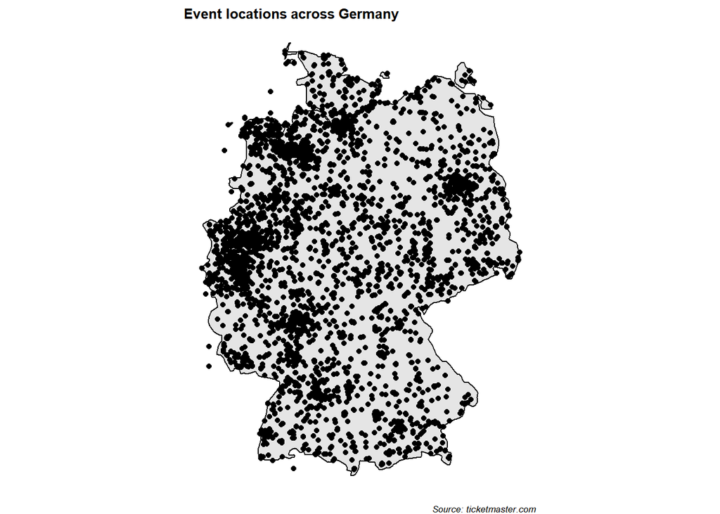

```r
region = "Germany"

plot_1 <- visualization(venue_data_2, 5.866944, 15.043611, 47.271679, 55.0846, region)
plot_1
```

## 6 Event locations in other countries

To see the event locations across the Netherlands, the prior functions are reused with new parametrizations. Therefore, `country` is now set to `"NL"`.

The rules for using the API remain unchanged with a maximum of 5000 API calls per day with a rate limitation of 5 requests per second.

A first quest for the event venues across the Netherlands yields the following result:

```r
# Task 2 and 3
country = "NL"

response_2 <- first.quest(country, tm_key)
content_2 <- content(response_2)

venue_data_3 <- first.df(response_2, content_2)

glimpse(venue_data_3)
```

```
## Rows: 20
## Columns: 7
## $ name       <chr> "Klokgebouw", "Chasse Theater", "Het Concertgebouw Grote...
## $ city       <chr> "Eindhoven", "Breda", "Amsterdam", "Amsterdam", "Rotterd...
## $ postalCode <chr> "5617 AB", "4811 DK", "1071 LN", "1018 EM", "3012 CL", N...
## $ address    <chr> "Klokgebouw 50", "Claudius Prinsenlaan 8", "Concertgebou...
## $ url        <chr> "https://www.ticketmaster.nl/venue/klokgebouw-eindhoven-...
## $ longitude  <dbl> 5.45788, 4.78182, 4.87830, 4.90388, 4.47318, 4.47846, 6....
## $ latitude   <dbl> 51.44836, 51.58734, 52.35587, 52.36237, 51.92174, 51.922...
```

The status of the response is 200, which indicates the success of the request. `content()` delivers a list of length 3 that supports on understanding the data. The element `_embedded` contains the 20 venues, that are returned. The element `links` contains pointers to the current page as well as to the first, the next and the last page. The element `page` specifies the response: the returned page consists of 20 items, in total there are 1984 elements that are stored on 100 pages.

The maximum of `500` elements per page does still hold. So, `size = 500` in the function call.

Reusing `second.quest(country, size, key)` with the adjusted parametrization yields the following result:

```r
# Task 4
venue_data_4 <- second.quest(country, 500, tm_key)

glimpse(venue_data_4)
```

```
## Rows: 1,984
## Columns: 7
## $ name       <chr> "Klokgebouw", "Chasse Theater", "Het Concertgebouw Grote...
## $ city       <chr> "Eindhoven", "Breda", "Amsterdam", "Amsterdam", "Rotterd...
## $ postalCode <chr> "5617 AB", "4811 DK", "1071 LN", "1018 EM", "3012 CL", N...
## $ address    <chr> "Klokgebouw 50", "Claudius Prinsenlaan 8", "Concertgebou...
## $ url        <chr> "https://www.ticketmaster.nl/venue/klokgebouw-eindhoven-...
## $ longitude  <dbl> 5.45788, 4.78182, 4.87830, 4.90388, 4.47318, 4.47846, 6....
## $ latitude   <dbl> 51.44836, 51.58734, 52.35587, 52.36237, 51.92174, 51.922...
```

The values that determine the borders of the Netherlands have been derived from the extreme points of the Netherlands as listed on [Wikipedia](https://en.wikipedia.org/wiki/List_of_extreme_points_of_the_Netherlands).

The plot of the event venues across the Netherlands is displayed in the following:

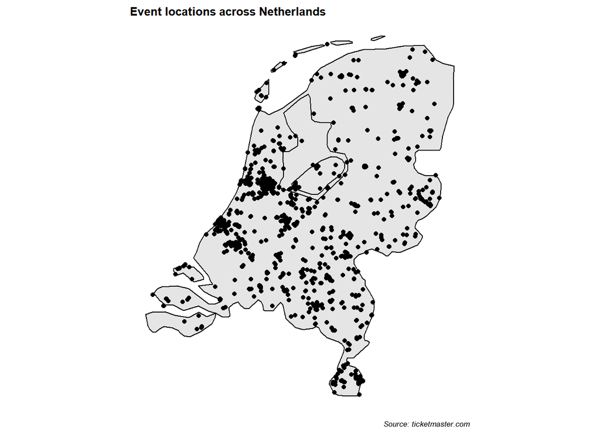

```r
# Task 5
region = "Netherlands"

# Northernmost point in sea, but identical results
plot_2 <- visualization(venue_data_4, 3.358333, 7.227778, 50.750417, 53.555, region)
plot_2
```